# Prediction of Dumbell Exercises using the Human Activity Recognition Dataset

David M.

2017-08-02

## Synopsis

This report provides an analysis of the Human Activity Recognition [dataset](http://web.archive.org/web/20161224072740/http:/groupware.les.inf.puc-rio.br/har) for weight lifting excersises to classify 5 different movements of dumbell exercises. Six young health participants were asked to perform one set of 10 repetitions of the Unilateral Dumbbell Biceps Curl in five different fashions: exactly according to the specification (Class A), throwing the elbows to the front (Class B), lifting the dumbbell only halfway (Class C), lowering the dumbbell only halfway (Class D) and throwing the hips to the front (Class E).

## Loading and Processing the Raw Data

The training set consists of 19,622 records with 160 variables associated with the exercise movements. The training set was separated into a training (60%) and test (40%) set for cross validation. The results of the analysis will be applied to predict the classes of the ‘testing’ set consisting of 20 movements.

```r
weight <- read.csv("pml-training.csv", header = TRUE, stringsAsFactors = FALSE)
set.seed(731364)
inTrain = createDataPartition(weight$classe, p = 0.6, list = FALSE)
wTraining = weight[inTrain,]
wTesting = weight[-inTrain,]
weightVal <- read.csv("pml-testing.csv", header = TRUE, stringsAsFactors = FALSE)
data.frame( Set = c("Original Training", "New Training", "New Testing", "Final Test"), NunRow= c(nrow(weight), nrow(wTraining), nrow(wTesting), nrow(weightVal)))
```

```
##                 Set NunRow
## 1 Original Training  19622
## 2      New Training  11776
## 3       New Testing   7846
## 4        Final Test     20
```

### Data Processing: Removing Unnecessary Variables

All the remaining attributes are continuous variables of the barbell movements. Some variables are highly correlated so PCA, where possible, will be used in the pre processing during the model selection.

Additionally, some of the variables (e.g. roll_belt) have high variability. As such, the variables will be centered and scaled, where possible, using the pre processing setting during the model selection.

```r
varNAs <- as.matrix(sapply(wTraining, function(x) sum(is.na(x)), simplify = TRUE))
highNAs <-which(varNAs[,1]>10000)

wTrainMod <- wTraining[,-c(1:7,highNAs)]
nearZeros <-nearZeroVar(wTrainMod)
wTrainMod <- wTrainMod[,-nearZeros]
wTrainMod$classe <- as.factor(wTrainMod$classe)
wTestMod <- wTesting[,-c(1:7,highNAs)]
wTestMod <- wTestMod[,-nearZeros]
wTestMod$classe <- as.factor(wTestMod$classe)
```

## Model Selection

Several models will be tested with a focus on accuracy; processing time will not be a significant criteria to select the model. The models that will be tested are: Random Forest, Regression Trees, Linear Discriminant Analysis and Stochastic Gradient Boosting.

```r
modRF <- randomForest(classe ~ ., data=wTrainMod, importance=TRUE, metric="Accuracy", prePros=c("pca","center","scale"),pcaComp=2, prox=TRUE)
modLDA <- train(classe ~ ., method="lda",data=wTrainMod,metric="Accuracy",  prePros=c("pca","center","scale"),pcaComp=2)
modRPART <- train(classe ~ ., method="rpart",data=wTrainMod,metric="Accuracy")
modGBM <- train(classe ~ ., method="gbm",data=wTrainMod,metric="Accuracy", verbose=FALSE)
```

The in-sample error rate for the Random Forest is low as the model has an 100% accuracy rate. As such, that model will be selected.

```r
data.frame( Model = c("Random Forest", "Linear Discrimate Analysis","Regression Trees", "Stochastic Gradient Boosting"),Accuracy =c(
confusionMatrix(predict(modRF,wTrainMod),wTrainMod$classe)$overall['Accuracy'][[1]],
confusionMatrix(predict(modLDA,wTrainMod),wTrainMod$classe)$overall['Accuracy'][[1]],
confusionMatrix(predict(modRPART,wTrainMod),wTrainMod$classe)$overall['Accuracy'][[1]],
confusionMatrix(predict(modGBM,wTrainMod),wTrainMod$classe)$overall['Accuracy'][[1]]))
```

```
##                          Model  Accuracy
## 1                Random Forest 1.0000000
## 2   Linear Discrimate Analysis 0.7041440
## 3             Regression Trees 0.4845448
## 4 Stochastic Gradient Boosting 0.9703635
```

## Results

A plot of the class centers for the top two most important variables from the varImp function shows that there is overlap between the different classes and that the prediction model utilizes many variables to classify the movements. Also displayed is a plot of the prediction accuracy for the test shows results from the random forest model.

The prediction function shows the predicted values for the 20 movements in the ‘testing’ set.

```r
modRF
```

```
##
## Call:
##  randomForest(formula = classe ~ ., data = wTrainMod, importance = TRUE,      metric = "Accuracy", prePros = c("pca", "center", "scale"),      pcaComp = 2, prox = TRUE)
##                Type of random forest: classification
##                      Number of trees: 500
## No. of variables tried at each split: 7
##
##         OOB estimate of  error rate: 0.66%
## Confusion matrix:
##      A    B    C    D    E class.error
## A 3344    4    0    0    0 0.001194743
## B   13 2262    4    0    0 0.007459412
## C    0   17 2036    1    0 0.008763389
## D    0    0   29 1900    1 0.015544041
## E    0    0    1    8 2156 0.004157044
```

```r
confusionMatrix(predict(modRF,wTestMod),wTestMod$classe)
```

```
## Confusion Matrix and Statistics
##
##           Reference
## Prediction    A    B    C    D    E
##          A 2227   10    0    0    0
##          B    4 1504    6    0    0
##          C    0    4 1361   24    2
##          D    0    0    1 1262    5
##          E    1    0    0    0 1435
##
## Overall Statistics
##
##                Accuracy : 0.9927
##                  95% CI : (0.9906, 0.9945)
##     No Information Rate : 0.2845
##     P-Value [Acc > NIR] : < 2.2e-16
##
##                   Kappa : 0.9908
##  Mcnemar's Test P-Value : NA
##
## Statistics by Class:
##
##                      Class: A Class: B Class: C Class: D Class: E
## Sensitivity            0.9978   0.9908   0.9949   0.9813   0.9951
## Specificity            0.9982   0.9984   0.9954   0.9991   0.9998
## Pos Pred Value         0.9955   0.9934   0.9784   0.9953   0.9993
## Neg Pred Value         0.9991   0.9978   0.9989   0.9964   0.9989
## Prevalence             0.2845   0.1935   0.1744   0.1639   0.1838
## Detection Rate         0.2838   0.1917   0.1735   0.1608   0.1829
## Detection Prevalence   0.2851   0.1930   0.1773   0.1616   0.1830
## Balanced Accuracy      0.9980   0.9946   0.9951   0.9902   0.9975
```

```r
predict(modRF,weightVal)
```

```
##  1  2  3  4  5  6  7  8  9 10 11 12 13 14 15 16 17 18 19 20
##  B  A  B  A  A  E  D  B  A  A  B  C  B  A  E  E  A  B  B  B
## Levels: A B C D E
```

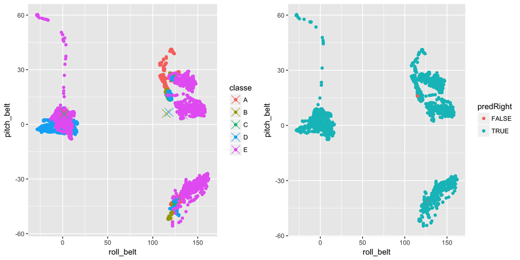

```r
rollP <- classCenter(wTrainMod[,c(1,2)], wTrainMod$classe, modRF$proximity)
rollP <- as.data.frame(rollP); rollP$classe <- rownames(rollP)
p1 <- qplot(roll_belt, pitch_belt, col=classe,data=wTrainMod)
p1 <- p1+geom_point(aes(x=roll_belt,y=pitch_belt, col=classe), size=5, shape=4, data=rollP)
pred <- predict(modRF,wTestMod); wTestMod$predRight <- pred==wTestMod$classe
p2 <- qplot(roll_belt, pitch_belt,colour=predRight, data=wTestMod)
grid.arrange(p1, p2, ncol=2)
```

## Appendix

### Exploratory Analysis

During the exploratory analysis, the structure and layout of the data was assessed. Due to the dimensions of the data and the report size limits, the output has been omitted and only a sample of the formulas are included.

```r
head(wTraining)
tail(wTraining)
str(wTraining)
summary(wTraining)
varNAs <- as.matrix(sapply(wTraining, function(x) sum(is.na(x)), simplify = TRUE))
var(wTrainMod)
cor <- findCorrelation(cor(wTrainMod[,-53]), cutoff = 0.75,verbose = TRUE)
pm <- ggpairs(wTraining,columns = 8:10, ggplot2::aes(colour=classe))
qplot(classe, pitch_belt, data=wTraining[wTraining$user_name=="carlitos",],geom = c("boxplot"))
qplot(classe, pitch_belt, data=wTraining[wTraining$user_name=="eurico",],geom = c("boxplot"))
```